# Data Handling: Import, Cleaning and Visualisation

Lecture 2: Tutorials

Author

Dr. Aurélien Sallin

# Tutorials

## Tutorial 1: a function to compute the mean

The mean is defined as

$\bar{x} = \frac{1}{n}\sum_{i=1}^n x_i.$

Write a function `meaN(x)` that computes the mean of a numeric vector. We are not allowed to call it “mean” because `mean()` is already a function in R.

Test that `meaN(c(1, 3, 5, 3, 2))` returns 2.8.

```r
meaN <- function(x) {
  # your code
}
```

**Solution**

```r
# No solution posted
```

## Tutorial 2: on slow and fast sloths

We can use loops to simulate natural processes over time. Write a program that calculates the populations of two kinds of sloths over time. At the beginning of year 1, there are **1000 slow sloths** and **1 fast sloth**. This one fast sloth is a new mutation that is genetically able to use roller blades. Not surprisingly, being fast gives it an advantage, as it can better escape from predators.

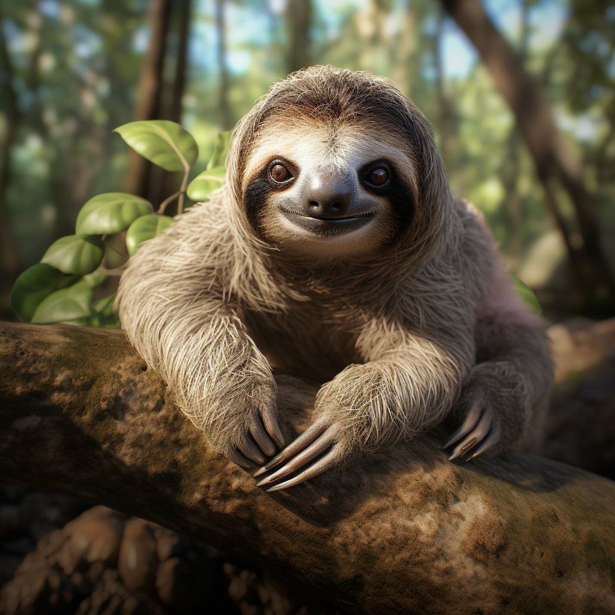

A slow sloth

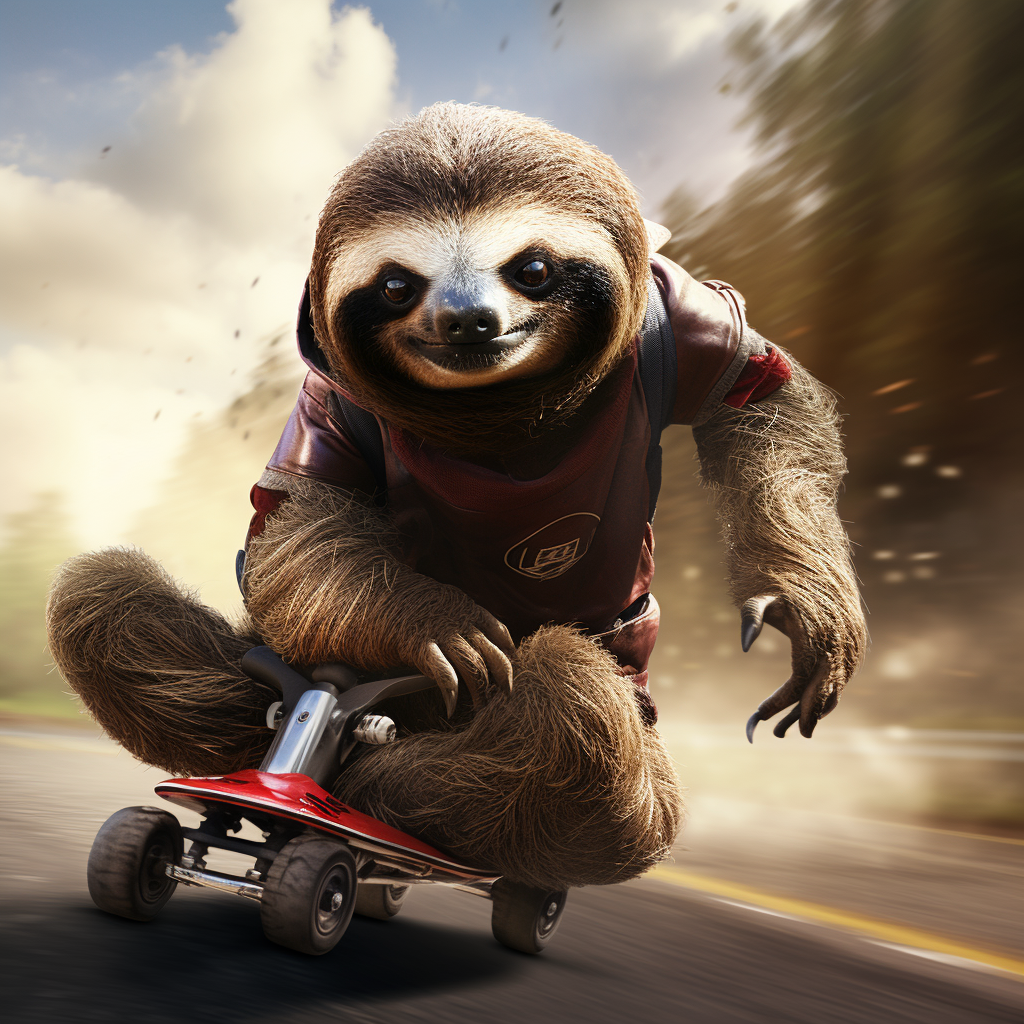

A fast sloth in its natural element

Each year, each sloth has one offspring. There are no further mutations, so slow sloths beget slow sloths, and fast sloths beget fast sloths. Also, each year 40% of all slow sloths die each year, while only 30% of the fast sloths do.

At the beginning of year one there are 1000 slow sloths. Another 1000 slow sloths are born. But, 40% of these 2000 slow sloths die, leaving a total of 1200 at the end of year one. Meanwhile, in the same year, we begin with 1 fast sloth, 1 more is born, and 30% of these die, leaving 1.4.

| Beginning of Year | Slow Sloths | Fast Sloths |
| --- | --- | --- |
| 1 | 1000 | 1 |
| 2 | 1200 | 1.4 |
| 3 | 1440 | 1.96 |

**Enter the first year in which the fast sloths outnumber the slow sloths.**

```r
# your code
```

**Solution**

```r
i <- 1
Nslow <- 1000
Nfast <- 1

while (Nslow > Nfast) {
  Nslow <- (Nslow * 2) * 0.6
  Nfast <- (Nfast * 2) * 0.7
  i <- i + 1
}

i

# Optional check
Nslow <- 1000; Nfast <- 1
for (k in 1:48) {
  Nslow <- c(Nslow, (Nslow[k] * 2) * 0.6)
  Nfast <- c(Nfast, (Nfast[k] * 2) * 0.7)
}
# tail(Nslow); tail(Nfast)
```

```
[1] 46
```

## Tutorial 3: a loop function

Create a function that repeatedly appends the sum of the current last three elements of a vector `lst` to `lst`, looping 25 times. Hint: use `append()` and `tail()`.

```r
appendsums <- function(lst) {
  # your code
}

# Example to test:
# sum_three <- c(0, 1, 2)
# appendsums(sum_three)
# After running, check: sum_three[10] == 125
```

**Solution**

```r
appendsums <- function(lst){
  for (i in 1:25) {
    lst <- append(lst, sum(tail(lst, 3)))
  }
  lst
}

sum_three <- c(0, 1, 2)
sum_three <- appendsums(sum_three)
sum_three[10]
```

```
[1] 125
```